# Lottery_test

## Neural-Network 를 활용한 Lotter 번호 예측

모바일 버전으로 보기

### 개발 동기

조금 더 쉽게 기계학습 이라는 개념에 다가서기 위하여, 주변에 흥미있는 문제로 접근해보면 어떨까 라는 생각이 들었다.

그 중 가장 간단하며 예측에 실패했을 때 비교적 작은 리스크를 가진 문제인 도박문제 - 로또문제를 풀어보고자 했다.

### 개발 환경

- python 2.7
- scikit-learn 0.18.1
- numpy 1.11.3
- scipy 0.18.1

### 예측 모델

현재 풀려고 하는 문제는 다음과 같이 정의할 수 있다.

$$F(X,N) = Y$$

,where

$Y = $그 다음 회차의 번호

이 모델의 예측이 성립하기 위해서는 최근 $N$번 까지의 출현 횟수가 현재의 시행에 영향을 미친다는 전제가 성립되어야한다.

예측을 평가하는 방법은 1~45까지의 번호를 나올 확률에 따라 정렬한 뒤 실제 정답지랑 비교하여 ROC curve 의 아래 면적인 AUC 값으로 평가하도록 한다.

무작위적 추정의 경우 AUC 값은 0.5의 값을 가진다. AUC 값이 1에 가까울수록 완벽한 예측이라고 볼 수 있다.

ROC curve 참조: https://ko.wikipedia.org/wiki/%EC%88%98%EC%8B%A0%EC%9E%90_%EC%A1%B0%EC%9E%91_%ED%8A%B9%EC%84%B1

```python
import lottery as lt
import numpy as np
import matplotlib.pyplot as plt
%matplotlib inline
```

**input L: datatxt**

- 이제까지 당첨된 역대 로또 번호 데이터

```python
datatxt = np.loadtxt('data.txt')
hello = lt.Lottery(datatxt)
```

```python
L = hello.datatxt
L[1:]
```

```
array([[  3.,   4.,  16., ...,  28.,  44.,  17.],
       [  1.,   2.,  15., ...,  24.,  36.,  12.],
       [ 12.,  14.,  24., ...,  34.,  45.,  41.],
       ...,
       [ 11.,  16.,  19., ...,  27.,  31.,  30.],
       [  9.,  13.,  21., ...,  32.,  42.,   2.],
       [ 10.,  23.,  29., ...,  37.,  40.,  16.]])
```

**F(N): hello.MLL(N)**

- 최근 N번 까지의 출현 빈도를 기반으로 학습

```python
AUC = np.array([])

for i in range(2, 50):
    hello.MLL(i)
    mean_auc = hello.Test()
    AUC = np.append(AUC,mean_auc)
```

```
0.516084024494
0.517230576441
0.507340720222
0.502099664054
0.501475462851
0.505475645636
0.506217466744
0.508563074353
0.509314015376
0.51411910458
0.509463313456
0.510272774961
0.509509066785
0.510987289653
0.512614367243
0.511988813497
0.512160029704
0.51600093985
0.517179023508
0.517760748024
0.521824040621
0.523051048674
0.519598997494
0.519482828693
0.5183592543
0.518327067669
0.514455151964
0.517024704619
0.520676691729
0.519819770013
0.525109415329
0.526144907724
0.524725274725
0.526139567669
0.524973147154
0.522344166869
0.517872550228
0.51444235589
0.51526060915
0.519866476536
0.520247988392
0.521213748657
0.523752563226
0.524784182679
0.521244148106
0.52009832273
0.523109243697
0.524248120301
```

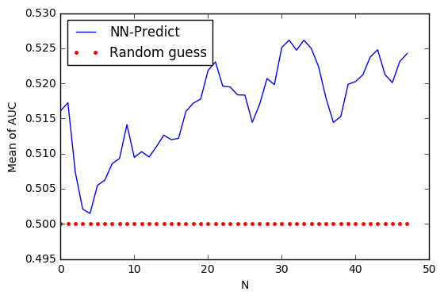

```python
plt.plot(AUC)
plt.plot(np.linspace(0.5,0.5,AUC.size),'r.')
plt.xlabel("N")
plt.ylabel("Mean of AUC")

plt.legend(('NN-Predict','Random guess'),loc='upper left')
```

상단의 그래프를 살펴보면, Neural-Network를 통해서 학습한 결과물이 무작위적 추정의 경우보다 평균 1%~2% AUC 값이 높아진다는 사실을 알 수 있다.

그래프를 살펴보면 N 이 클수록 AUC의 평균도 높아지는 경향을 보인다는 것을 확인 할 수 있다.

해석하면, 과거의 로또 데이터를 20개 이상 학습시킨 결과가 무작위 추정보다 맞출 확률이 매우 작게나마 증가한다는 사실을 확인할 수 있다.

```python
Y = hello.returnLotterynum()[1]
```